# Hands-on Project

**Question 1:** List the dataset(s) you chose for this project from the [UCI Machine Learning respository](https://archive.ics.uci.edu/ml/datasets.php).

1. Absenteeism at work Data Set (https://archive.ics.uci.edu/ml/datasets/Absenteeism+at+work)

**Question 2:** Describe the dataset in your own words. How many data points, how many attributes, how many types of attributes, how many classes (if any)? Who collected it? How was it collected?

The dataset contains records of absenteeism at work from July 2007 to July 2010 at a courier company in Brazil.  
No. of Observations: 740,  
No. of Attributes: 21  
Types of attibutes: All numerical, but 10 of the attributes in reality are categorical variables already converted to numerics  
Attributes Description:  
ID - Unique Id for each employee, a total of 36 unique employees.  
Reason for absence - 0 to 28, with each number assuming a value for each reason.  
1 - Certain infectious and parasitic diseases  
2 - Neoplasms  
3 - Diseases of the blood and blood-forming organs and certain disorders involving the immune mechanism  
4 - Endocrine, nutritional and metabolic diseases  
5 - Mental and behavioural disorders  
6 - Diseases of the nervous system  
7 - Diseases of the eye and adnexa  
8 - Diseases of the ear and mastoid process  
9 - Diseases of the circulatory system  
10 - Diseases of the respiratory system  
11 - Diseases of the digestive system  
12 - Diseases of the skin and subcutaneous tissue  
13 - Diseases of the musculoskeletal system and connective tissue  
14 - Diseases of the genitourinary system  
15 - Pregnancy, childbirth and the puerperium  
16 - Certain conditions originating in the perinatal period  
17 - Congenital malformations, deformations and chromosomal abnormalities  
18 - Symptoms, signs and abnormal clinical and laboratory findings, not elsewhere classified  
19 - Injury, poisoning and certain other consequences of external causes  
20 - External causes of morbidity and mortality  
21 - Factors influencing health status and contact with health services.  
22 - patient follow-up  
23 - medical consultation  
24 - blood donation  
25 - laboratory examination  
26 - unjustified absence  
27 - physiotherapy  
28 - dental consultation  
Month of absence - Month of absence from 0 to 12  
Day of the week - Monday through Friday represented as 2 to 6  
Seasons - 4 seasons 1 to 4  
Transportation expense - Expenses when travellinng to and from work  
Distance from Residence to Work - Distance from Residence to Work  
Service time - Years of experience in that company  
Age - Age  
Work load Average/day - Average workload per day  
Hit target - Hit target  
Disciplinary failure - Binary variable suggesting any disciplinary failures reported previously for the employee  
Education - high school (1), graduate (2), postgraduate (3), master and doctor (4)  
Son - # of childeren  
Social drinker - Binary Variable 0 if a non-drinker 1 otherwise  
Social smoker - Binary Variable 0 if a non-snoker 1 otherwise  
Pet - # of pets  
Weight - Weight of the employee  
Height - Height of the employee  
Body mass index - BMI of the employee  
Absenteeism time in hours - # of hours absent

Classes: None

**Question 3:** What is your goal? Specifically, what insights do you want to learn from this data. Please be aware that clustering, classification, or itemset mining are not 'insights'. These are data mining tasks. Insights are relevant to the domain from which the data is generated.

Goal: The primary goal is to come up with attributes which differentiate high absentees from low absentees, we then based on this analysis would like to suggest some measures to the management of the company that'd help them reduce absenteeism at work. We first transform the dataset into a new summary dataset with one row for one unique employee which would contain summary of that employee for all atrributes. After transforming the dataset now we divide the dataset into two class, marking people with low absenteeism (i.e total absenteeism for 3 years is less than 200) as '0' and people with high absenteeism (i.e total absenteeism for 3 years is greater than or equal to 200) as '1'. we also additionally propose a machine learning model which would predict the likelihood of a given person based on the attribute, since we're unlikely to have company specific data for any new employee, our model (prone to all kinds of prejudice because of the data itself) will most likely predict based on the demographics. If time permits we'd also like to analyze the causes behind such results.

**Question 4:** List the data mining task(s) and the specific algorithms you want to perform on this data. Do not pick the tasks listed in the 'Default Task' column on the UCI page.

1. Do EDA to select relevant features
2. Perform clustering ( Kmeans, GMM, DBScan, Agglomeartive, Spectral), to see if the selected features separate the data and also gauge the shape and density of the points in feature space to select appropriate classifier
3. If we're able to separate the points as we expect to we'd like to implement any of the probablity based classifier such as decision tree or Naive Bayes

**Question 5:** Before selecting the methods you listed in response to Question 4, what are all methods you originally considered to use for the selected data mining task? What was your rationale for selecting the methods you listed in response to Question 4? What was your rationale for not selecting other methods?

Originally the idea was to do trail and error for each classifier learned in the course with all of the attributes, but after careful considerations of many other factors (such as the learning time for SVM algoritms and distortion due to noise), we decided we'd be better off if we correctly guess the data in feature space and then apply appropriate classifier on it.

**Question 6:** What limitations does your 'selected' method(s) has(have) that may limit your ability to accomplish the goal you have set for yourself?

There's a very good chance that our classes are not well defined ( good separation and good cohesiveness) and clustering doesn't reveal anything about the shape or the density of the data

**Question 7:** Do you have any alternative plan/strategy to overcome the above limitation(s)?

if nothing at all is revealed then in worst case we'd do a trial and error process to find the best classifier

**Question 8:** For each of the methods you want to use, what parameter choices do you want to use and why? It does not have to be one parameter choice, it could be a collection or a range of choices you may want to consider.

Clustering: Ideally We'd like to find 2 clusters (with no noise for DB Scan) for each of the algorithms  
Classfication: For Decision Tree we expect the max nodes to be in range of 3 to 8, we're expecting the selected space to be much lower than the original 21 dimensional space, anything more than 8 we think would overfit the data and anything less than 3 would cause underfitting. we don't have to worry about parameters for Naive Bayes.

**Question 9:** How will you evaluate that you are successful in your pursuing your goal at the end of the project? In other words, what is your evaluation criteria?

There're 3 part to the goal as initially mentioned

1. EDA: We'd consider ourselves successful if we're able to give atleast give 3 direct recommendations (i.e find some interesting relationships between the attributes) to the management based on the EDA
2. Clustering: Deduce most suitable classifier based clustering analysis done on the data
3. Classification: Considering the low training size (36 employees in total)Ideally we'd like our model to predict the probablity of an emplloyee being High Absentee atleast 2/3rd of the times correctly.

**Question 10:** How will you evaluate that you are successful in your pursuing your goal at the end of the project? In other words, what is your evaluation criteria?

There're 2 part to the goal as initially mentioned

1. We'd consider ourselves successful if we're able to give atleast give 3 direct recommendations to the management based on the EDA.
2. Classification: Considering the low training size (36 employees in total)Ideally we'd like our model to predict the probablity of an emplloyee being High Absentee atleast 2/3rd of the times correctly.

**Question 11:** Show any visualizations you may have generated to understand your data. Please include the code you used and the plots below. If you borrowed code (entirely or partially) from the hands-on projects or anywhere else, clearly provide a link to your source.

You may use this package to load UCI data in python: https://github.com/SkafteNicki/py_uci

# 1. EDA and Feature Selection

```python
import pandas as pd
import numpy as np
import matplotlib.pyplot as plt
import matplotlib.cm as cm
import seaborn as sns
```

```python
# Data Load
data = pd.read_excel('C:/Users/nifaullah/Downloads/Absenteeism_at_work_AAA/Absenteeism_at_work.xls')
# Transforming dataset from each absent record to user specific summary
testz = data.groupby(['ID'])[['Absenteeism time in hours']].sum()
testz['id'] = testz.index.values
high_absentees = testz[testz['Absenteeism time in hours'] > 200].iloc[:,1]
high_absentees_df = data[data['ID'].isin(high_absentees)]
low_absentees_df = data[~data['ID'].isin(high_absentees)]
# Removal of Columns which cannot be logically summarised
high_absentees_df_demo = high_absentees_df.drop(['Month of absence','Day of the week','Seasons', 'Reason for absence'], axis = 1)
low_absentees_df_demo = low_absentees_df.drop(['Month of absence','Day of the week','Seasons', 'Reason for absence'], axis = 1)
# Creating user specific summary dataset
high_absentees_df_demo1 = high_absentees_df_demo.groupby('ID').agg(
    {'ID': 'mean',
     'Transportation expense': 'mean',
     'Distance from Residence to Work': 'mean',
     'Service time': 'mean',
     'Age': 'mean',
     'Hit target': 'mean',
     'Disciplinary failure': 'mean',
     'Son': 'mean',
     'Social drinker': 'mean',
     'Social smoker': 'mean',
     'Pet': 'mean',
     'Education': 'mean',
     'Body mass index': 'mean',
     'Absenteeism time in hours': ['mean', 'sum']
    })
low_absentees_df_demo1 = low_absentees_df_demo.groupby('ID').agg(
    {'ID': 'mean',
     'Transportation expense': 'mean',
     'Distance from Residence to Work': 'mean',
     'Service time': 'mean',
     'Age': 'mean',
     'Hit target': 'mean',
     'Disciplinary failure': 'mean',
     'Son': 'mean',
     'Social drinker': 'mean',
     'Social smoker': 'mean',
     'Pet': 'mean',
     'Education': 'mean',
     'Body mass index': 'mean',
     'Absenteeism time in hours': 'mean',
     'Absenteeism time in hours': ['mean', 'sum']
    })
# Concatenate users
result = pd.concat([high_absentees_df_demo1, low_absentees_df_demo1])
# Create Class Column to specify class of each users based on Absenteeism time in hours
result['class'] = result['Absenteeism time in hours']['sum'].apply(lambda x: 0 if x < 200
                                                                           else 1)

result.columns = ['ID', 'Transportation expense', 'Distance from Residence to Work', 'Service time', 'Age', 'Hit target',
                  'Disciplinary failure', 'Son', 'Social drinker', 'Social smoker', 'Pet', 'Education', 'Body mass index',
                  'Absenteeism time in hours Mean', 'Absenteeism time in hours Sum', 'class']
```

```python
result.head()
```

| ID | ID | Transportation expense | Distance from Residence to Work | Service time | Age | Hit target | Disciplinary failure | Son | Social drinker | Social smoker | Pet | Education | Body mass index | Absenteeism time in hours Mean | Absenteeism time in hours Sum | class |
| --- | --- | --- | --- | --- | --- | --- | --- | --- | --- | --- | --- | --- | --- | --- | --- | --- |
| 3 | 3 | 179 | 51.0 | 18.0 | 38.0 | 95.070796 | 0.008850 | 0.0 | 1.0 | 0 | 0 | 1.0 | 31.0 | 4.265487 | 482 | 1 |
| 9 | 9 | 228 | 14.0 | 16.0 | 58.0 | 95.875000 | 0.000000 | 2.0 | 0.0 | 0 | 1 | 1.0 | 22.0 | 32.750000 | 262 | 1 |
| 11 | 11 | 289 | 36.0 | 13.0 | 33.0 | 93.850000 | 0.050000 | 2.0 | 1.0 | 0 | 1 | 1.0 | 30.0 | 11.250000 | 450 | 1 |
| 14 | 14 | 155 | 12.0 | 14.0 | 34.0 | 95.689655 | 0.000000 | 2.0 | 1.0 | 0 | 0 | 1.0 | 25.0 | 16.413793 | 476 | 1 |
| 15 | 15 | 291 | 31.0 | 12.0 | 40.0 | 92.594595 | 0.054054 | 1.0 | 1.0 | 0 | 1 | 1.0 | 25.0 | 6.837838 | 253 | 1 |

```python
result.tail()
```

| ID | ID | Transportation expense | Distance from Residence to Work | Service time | Age | Hit target | Disciplinary failure | Son | Social drinker | Social smoker | Pet | Education | Body mass index | Absenteeism time in hours Mean | Absenteeism time in hours Sum | class |
| --- | --- | --- | --- | --- | --- | --- | --- | --- | --- | --- | --- | --- | --- | --- | --- | --- |
| 30 | 30 | 157 | 27.0 | 6.0 | 29.0 | 93.714286 | 0.142857 | 0.0 | 1.0 | 1 | 0 | 1.0 | 22.0 | 4.428571 | 31 | 0 |
| 31 | 31 | 388 | 15.0 | 9.0 | 50.0 | 96.666667 | 0.333333 | 0.0 | 0.0 | 0 | 0 | 1.0 | 24.0 | 5.333333 | 16 | 0 |
| 32 | 32 | 289 | 48.0 | 29.0 | 49.0 | 92.600000 | 0.000000 | 0.0 | 0.0 | 0 | 2 | 1.0 | 36.0 | 3.200000 | 16 | 0 |
| 33 | 33 | 248 | 25.0 | 14.0 | 47.0 | 94.791667 | 0.041667 | 2.0 | 0.0 | 0 | 1 | 1.0 | 32.0 | 3.041667 | 73 | 0 |
| 35 | 35 | 179 | 45.0 | 14.0 | 53.0 | 95.000000 | 0.000000 | 1.0 | 0.0 | 0 | 1 | 1.0 | 25.0 | 0.000000 | 0 | 0 |

First let's see if we there is any particular day of the week (like weekends) where people are absent more

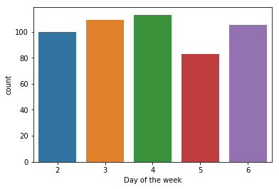

```python
sns.countplot(x ='Day of the week', data = data[data['ID'].isin(high_absentees)])
```

Turns out there isn't much big of a difference, but people are less absent on Thursday are slightly less, so may be management if it plans to conduct any important activity for entire employees it can conduct on Thursday

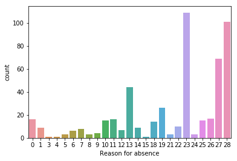

```python
sns.countplot(x ='Reason for absence', data = data[data['ID'].isin(high_absentees)])
```

Medical consultation and Dental consultation seems to be most popular reason People with high absenteeism

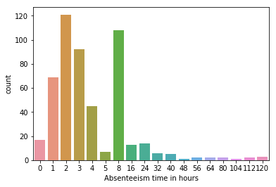

```python
sns.countplot(x ='Absenteeism time in hours', data = data[data['ID'].isin(high_absentees)])
```

People with high absenteeism mostly seem to be absent either mostly for 2 hours or 8 hours. Now let's see what're the most popular reasons for 2 hr absentation. Also there're small chunks of employees who have long continuos absentation suggesting some extended, we'd also like to know most common reason for such long absentation.

```python
high_abs = data[data['ID'].isin(high_absentees)]
low_abs = data[~data['ID'].isin(high_absentees)]
```

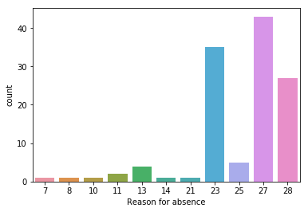

```python
sns.countplot(x ='Reason for absence', data = high_abs[high_abs['Absenteeism time in hours'] == 2])
```

A large number of people are taking 2 hour absentation for physiotherapy, medical consultation and dental consultation, which seems absurd. One course of action for the management may be to put up monthly dental or medical camps, this would most likely cut down the absentation by huge amount.

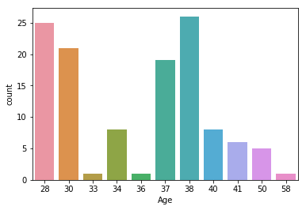

```python
sns.countplot(x ='Age', data = high_abs[high_abs['Absenteeism time in hours'] == 2])
```

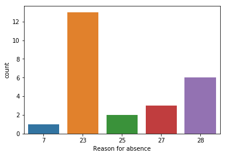

```python
sns.countplot(x ='Reason for absence', data = high_abs[(high_abs['Absenteeism time in hours'] == 2) & (high_abs['Age'] == 28)])
```

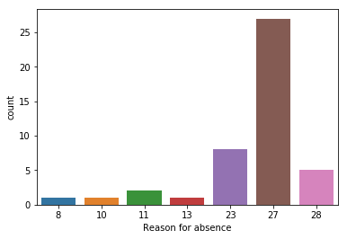

```python
sns.countplot(x ='Reason for absence', data = high_abs[(high_abs['Absenteeism time in hours'] == 2) & (high_abs['Age'].isin([37,38]))])
```

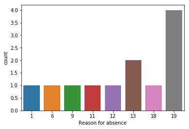

```python
sns.countplot(x ='Reason for absence', data = high_abs[high_abs['Absenteeism time in hours'] >= 50])
```

Nothing suspicious here, people taking long leaves for Injury, poisoning and certain other consequences of external causes seems perfectly reasonable

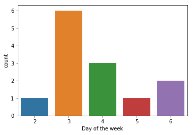

```python
sns.countplot(x ='Day of the week', data = high_abs[(high_abs['Absenteeism time in hours'] == 2) & (high_abs['Age'] == 28)
                                                    & (high_abs['Reason for absence'] == 23)])
```

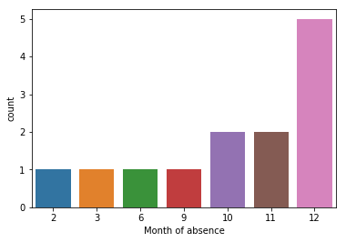

```python
sns.countplot(x ='Month of absence', data = high_abs[(high_abs['Absenteeism time in hours'] == 2) & (high_abs['Age'] == 28)
                                                    & (high_abs['Reason for absence'] == 23)])
```

Day of the week and Month of absence doesn't reveal any suspicious pattern

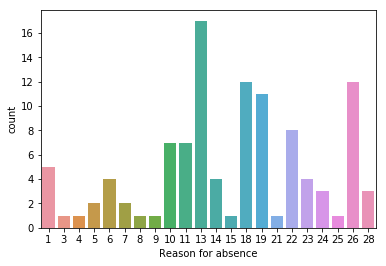

```python
sns.countplot(x ='Reason for absence', data = high_abs[high_abs['Absenteeism time in hours'] == 8])
```

People with muscoskeletal problems seems to be most with 8hrs absentations which seems to be genuine.

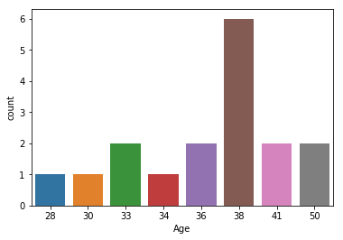

```python
sns.countplot(x ='Age', data = high_abs[(high_abs['Absenteeism time in hours'] == 8)
                                        & (high_abs['Reason for absence'] == 13)])
```

Nothing out of place is here

```python
full_df = pd.concat([high_abs, low_abs])
```

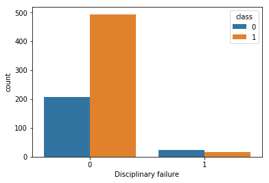

```python
sns.countplot(x = 'Disciplinary failure', hue = 'class', data = full_df)
```

People with low absenteeism rate have proportionately higher representative in disciplinary failures, this could suggest that people who have been dealt with disciplinary action tend to be absent less.

Again another course of action for the management here can be to proceed with disciplinary action for any excessive absenteesim, evidence from the above graph suggest this would most likely aid in reducing the absenteeism

```python
high_abs.columns
```

```
Index(['ID', 'Reason for absence', 'Month of absence', 'Day of the week',
       'Seasons', 'Transportation expense', 'Distance from Residence to Work',
       'Service time', 'Age', 'Work load Average/day ', 'Hit target',
       'Disciplinary failure', 'Education', 'Son', 'Social drinker',
       'Social smoker', 'Pet', 'Weight', 'Height', 'Body mass index',
       'Absenteeism time in hours', 'class'],
      dtype='object')
```

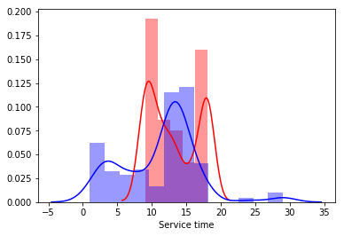

```python
sns.distplot(high_abs['Service time'], color = 'red')
sns.distplot(low_abs['Service time'], color = 'blue')
```

This again fits well with our earlier age analysis, employees with 8 - 12 years of service time display high absenteeism, most employee with service time betweeen 13 -17 years show low absenteeism and again employees with 18 - 21 years of service time are showimg igh absenteeism.

This is a very strange cluster with people different belonging age groups on either side of a thick region behave similarly.Due to the difference in their service time and ages we can rule out common cause.

Employees with 8 -12 years of experience generally have a very young family to deal with (again we cannot comment more on this because of lack of data) but this could be one of the hypothesis. Management can take steps such as installation of a Day care center or moving the office near to the closest school district might help reducing the absenteeism problem for this group.

Employees with 18 - 21 years of experience generally are very hard to motivate, inaddtion to the expected health issues. Management can run programs to motivate such employees, thus helping the in the curbing of absenteeism

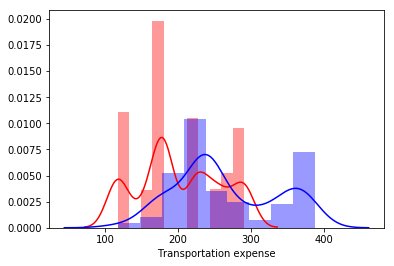

```python
sns.distplot(high_abs['Transportation expense'], color = 'Red')
sns.distplot(low_abs['Transportation expense'], color = 'Blue')
```

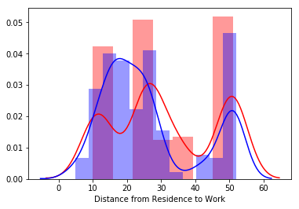

```python
sns.distplot(high_abs['Distance from Residence to Work'], color = 'Red')
sns.distplot(low_abs['Distance from Residence to Work'], color = 'Blue')
```

People who have less transportation expenses seem to be more absent but yet distance from residence to work doesn't show the same trend, suggesting that these employees may well be using public transport service to reach office which is often causing the delay or excessive absenteeism of 2 hours.

We need further analysis on this, if the above hypothesis is provn to be true, perhaps the management can run it's own transportation service to reduce absenteeism

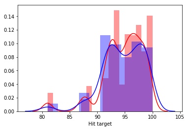

```python
sns.distplot(high_abs['Hit target'], color = 'Red')
sns.distplot(low_abs['Hit target'], color = 'Blue')
```

Nothing of note here

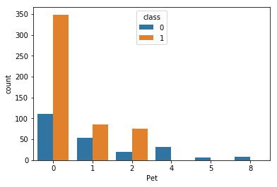

```python
sns.countplot(x='Pet', hue = 'class', data = full_df)
```

Ineteresting with no pet are more prone to absenteeism, we need to investigate more before we claim anything

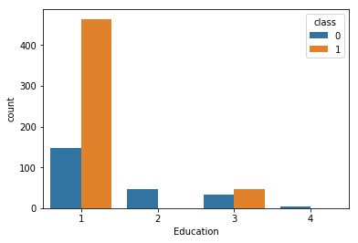

```python
sns.countplot(x='Education', hue = 'class', data = full_df)
```

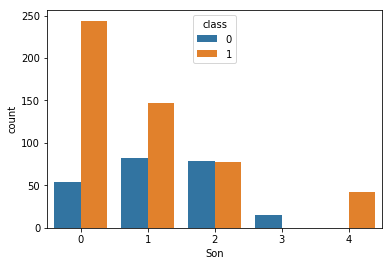

```python
sns.countplot(x='Son', hue = 'class', data = full_df)
```

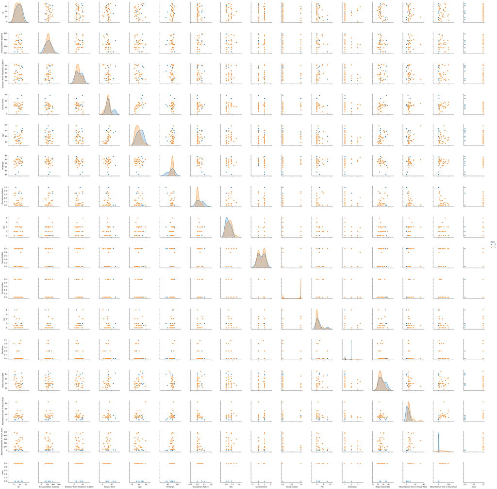

```python
sns.pairplot(result, hue='class')
```

Based on the above pairplots (more specfically the diagonal class wise distribution and the last column) and class wise univariate analysis (see plots and inferences above the pairplots) we narrow down to these features 'Transportation expense', 'Service time', 'Disciplinary failure', 'Pet'. We believe below features would help significantly to segregate the classes

```python
features = ['Transportation expense','Service time', 'Disciplinary failure',  'Pet', 'class']
```

**Question 12:** **Perform data mining, evaluate your work and report your findings.** This should include code, plots and results you may have generated. If you borrowed code (entirely or partially) from the hands-on projects or anywhere else, clearly provide a link to your source.

# 2. Data Analysis using different Clustering Algorithms

```python
from sklearn.mixture import GaussianMixture
from sklearn.cluster import AgglomerativeClustering
from sklearn.cluster import DBSCAN
from sklearn.cluster import SpectralClustering
from sklearn.cluster import KMeans

from scipy.special import comb
def rand_index(S, T):

    Spairs = comb(np.bincount(S), 2).sum()
    Tpairs = comb(np.bincount(T), 2).sum()

    A = np.c_[(S, T)]

    f_11 = sum(comb(np.bincount(A[A[:, 0] == i, 1]), 2).sum()
             for i in set(S))

    f_10 = Spairs - f_11
    f_01 = Tpairs - f_11
    f_00 = comb(len(A), 2) - f_11 - f_10 - f_01
    return (f_00 + f_11) / (f_00 + f_01 + f_10 + f_11)
```

```python
result['class'] = result['Absenteeism time in hours Sum'].apply(lambda x: 0 if x <= 200
                                                                           else 1)
```

```python
full_demo_df = result[features]
```

```python
test_demo_df = full_demo_df.iloc[:,0:4]
```

```python
test_demo_df.columns
```

[output not shown]

```python
test_demo_df.shape
```

```
(36, 4)
```

```python
kmeans = KMeans(n_clusters=2, random_state=10);
y_pred = kmeans.fit_predict(test_demo_df)
print(rand_index(y_pred, full_demo_df.iloc[:,-1]))
```

```
0.4857142857142857
```

Nearly half of the points are clustered correctly. This only seems to suggest that the clusters are not naturally well separated.

```python
gmm = GaussianMixture(n_components=2, covariance_type='full')
y_pred = gmm.fit_predict(test_demo_df)
print(rand_index(y_pred, full_demo_df.iloc[:,-1]))
```

```
0.5
```

Again suugesting that points are not well separated, the overlapping of data from different clusters messed up the probabilities to each distribution

```python
dbscan = DBSCAN(eps=37, min_samples=5)
y_pred = dbscan.fit_predict(test_demo_df)
sum(y_pred == -1)
```

```
4
```

```python
np.unique(y_pred)
```

```
array([-1,  0,  1], dtype=int64)
```

```python
print(rand_index(y_pred, full_demo_df.iloc[:,-1]))
```

```
0.5
```

The above results suggests that points within clusters are loosely coupled and scattered around

```python
single_linkage = AgglomerativeClustering(linkage="single", n_clusters=2)
y_pred = single_linkage.fit_predict(test_demo_df)
print(rand_index(y_pred, full_demo_df.iloc[:,-1]))
```

```
0.5634920634920635
```

```python
complete_linkage = AgglomerativeClustering(linkage="complete", n_clusters=2)
y_pred = complete_linkage.fit_predict(test_demo_df)
print(rand_index(y_pred, full_demo_df.iloc[:,-1]))
```

```
0.5253968253968254
```

```python
average_linkage = AgglomerativeClustering(linkage="average", n_clusters=2)
y_pred = average_linkage.fit_predict(test_demo_df)
print(rand_index(y_pred, full_demo_df.iloc[:,-1]))
```

```
0.49206349206349204
```

```python
n_clusters = 2
spectral = SpectralClustering(n_clusters=n_clusters, random_state=10)
y_pred = spectral.fit_predict(test_demo_df)
print(rand_index(y_pred, full_demo_df.iloc[:,-1]))
```

```
0.5428571428571428
```

Again reiterating the same points as above that the points intra cluster are not cohesive and inter cluster are not well separated

The above cluster analysis has made it really difficult for us to make a straight forward choice because we assumed we'd get a well separated space, but yet based on the features selected and derived feature space and shape from clustering analysis, we believe that decision tree because of it's axis paralell partioning system should do a reasonable job in comparison to other classifiers since we selected features such that it'd differentiate the classes. We believe Naive Bayes as opposed to assumed earlier is likely not to do as well as Decision Tree because data is scattered and classes most likely overlap

# 3. Classification: Test the conclusions of above cluster analysis

```python
#Classification Algorithms
from sklearn.tree import DecisionTreeClassifier
from sklearn.neighbors import KNeighborsClassifier
from sklearn.naive_bayes import GaussianNB
from sklearn.svm import SVC
```

```python
class_demo_df = full_demo_df.iloc[:,-1]
class_demo_df.shape
```

```
(36,)
```

```python
dt2 = DecisionTreeClassifier(max_depth=2)
dt4 = DecisionTreeClassifier(max_depth=4)
dt6 = DecisionTreeClassifier(max_depth=6)
dt8 = DecisionTreeClassifier(max_depth=8)
dt3 = DecisionTreeClassifier(max_depth=3)
dt5 = DecisionTreeClassifier(max_depth=5)
```

```python
dt2_score = cross_val_score(dt2, test_demo_df, class_demo_df, cv=10, scoring='accuracy')
dt4_score = cross_val_score(dt4, test_demo_df, class_demo_df, cv=10, scoring='accuracy')
dt6_score = cross_val_score(dt6, test_demo_df, class_demo_df, cv=10, scoring='accuracy')
dt8_score = cross_val_score(dt8, test_demo_df, class_demo_df, cv=10, scoring='accuracy')
dt3_score = cross_val_score(dt3, test_demo_df, class_demo_df, cv=10, scoring='accuracy')
dt5_score = cross_val_score(dt5, test_demo_df, class_demo_df, cv=10, scoring='accuracy')
```

```python
dt_accuracy = { 'Depth': [2,4,6,8,3,5],
    'Score': [dt2_score.mean(),dt4_score.mean(),dt6_score.mean(),dt8_score.mean(), dt3_score.mean(),
                          dt5_score.mean()]
                   }
dt_accuracy_df = pd.DataFrame.from_dict(dt_accuracy)
print(dt_accuracy_df)
```

```
   Depth     Score
0      2  0.565000
1      4  0.690000
2      6  0.693333
3      8  0.685000
4      3  0.665000
5      5  0.685000
```

69% accuracy for 6 rules seems very reasonable for such a small sample (36 employees) and also 6 rules for 4 attributes is also very reasonable.

```python
nb = GaussianNB()
nb_scores_1 = cross_val_score(nb, test_demo_df, class_demo_df, cv=10, scoring='accuracy')
nb_scores_1.mean()
```

```
0.6716666666666666
```

Surprisingly Naive Bayes also does a very reasonable job, considering that we were failing to naturally cluster the space. May be the fact that it assumes that probabability of each attribute to be independent of each other actually helps it to genarlize the feature space and saves from overfitting

Although our goal has been met, we'd like to test few other classifiers to see if our inference about the data being decision tree friendly because of the feature space and the results of cluster analysis, is true or not

```python
knn1 = KNeighborsClassifier(n_neighbors=1)
knn3 = KNeighborsClassifier(n_neighbors=3)
knn5 = KNeighborsClassifier(n_neighbors=5)
knn7 = KNeighborsClassifier(n_neighbors=7)
knn1_score = cross_val_score(knn1, test_demo_df, class_demo_df, cv=10, scoring='accuracy')
knn3_score = cross_val_score(knn3, test_demo_df, class_demo_df, cv=10, scoring='accuracy')
knn5_score = cross_val_score(knn5, test_demo_df, class_demo_df, cv=10, scoring='accuracy')
knn7_score = cross_val_score(knn7, test_demo_df, class_demo_df, cv=10, scoring='accuracy')
knn_accuracy_df = pd.DataFrame.from_dict({ 'Neighbours': [1,3,5,7],
    'Score': [knn1_score.mean(),knn3_score.mean(),knn5_score.mean(),knn7_score.mean()]})
print(knn_accuracy_df)
```

```
   Neighbours     Score
0           1  0.465000
1           3  0.431667
2           5  0.590000
3           7  0.648333
```

Knn doesn't perform as good as decision tree or naive bayes but it's performance improves with generalization. Again this is most likely to suffer because as we know classes are overlapping and scattered.

```python
svm_linear = SVC(C=0.1, kernel='linear')
svm_scores_1 = cross_val_score(svm_linear, test_demo_df, class_demo_df, cv=10, scoring='accuracy')
svm_scores_1.mean()
```

```
0.6100000000000001
```

```python
svm_linear = SVC(C=10, kernel='linear')
svm_scores_1 = cross_val_score(svm_linear, test_demo_df, class_demo_df, cv=10, scoring='accuracy')
svm_scores_1.mean()
```

```
0.6100000000000001
```

SVM Linear also as expected (because of the way how clustering panned out) fails to do as a good job as Decision Tree

```python
svm_rbf_001 = SVC(C = 0.5, kernel='rbf', gamma=0.01)
svm_rbf_01 = SVC(C = 0.5, kernel='rbf', gamma=0.1)
svm_rbf_1 = SVC(C = 0.5, kernel='rbf', gamma=1)
svm_rbf_scores_001 = cross_val_score(svm_rbf_001, test_demo_df, class_demo_df, cv=10, scoring='accuracy')
svm_rbf_scores_01 = cross_val_score(svm_rbf_01, test_demo_df, class_demo_df, cv=10, scoring='accuracy')
svm_rbf_scores_1 = cross_val_score(svm_rbf_1, test_demo_df, class_demo_df, cv=10, scoring='accuracy')
svm_rbf_accuracy_df = pd.DataFrame.from_dict({ 'Order': ['001','01','1'],
    'Score': [svm_rbf_scores_001.mean(),svm_rbf_scores_01.mean(),svm_rbf_scores_1.mean()]})
print(svm_rbf_accuracy_df)
```

```
  Order     Score
0   001  0.693333
1    01  0.693333
2     1  0.693333
```

SVM RBF manages to match the accuracy of the decision tree, which tells us even after projecting the points into a higher dimensional space doesn't really improve upon the simple decision tree classifier

```python
svm_poly_scores = cross_val_score(SVC(C=0.01, kernel='poly',degree=1, gamma = 'auto'), test_demo_df, class_demo_df, cv=10, scoring='accuracy')
svm_poly_scores.mean()
```

```
0.6683333333333333
```

```python
svm_poly_scores = cross_val_score(SVC(C=0.01, kernel='poly',degree=2, gamma = 'auto'), test_demo_df, class_demo_df, cv=10, scoring='accuracy')
svm_poly_scores.mean()
```

```
0.4766666666666667
```

```python
svm_poly_scores = cross_val_score(SVC(C=0.01, kernel='poly',degree=3, gamma = 'auto'), test_demo_df, class_demo_df, cv=10, scoring='accuracy')
svm_poly_scores.mean()
```

```
0.45166666666666666
```

SVM Polynomial with degrees 1, 2 and 3 fail to improve the score of the decision tree. And additionally when we project the points in high dimensions accuracy decreases more, suggesting that similar points are not grouping as expected in higher dimensional space

# 4. Conclusion

We'd say that our approach, to understand the nature of the data in feature space with the application of clustering and classfication knowledge we posseses, has been reasonably successful.

# 5. References

Most code used here are from IDA Clustering and Classification Hands On excercise and practise. Accuracy measured are based on the reliable cross validation methodology

**Question 13:** Putting your findings in the context of your goal and evaluation plan, do you consider yourself successful? Provide reasons for your success or lack thereof.

Yes we consider ourselves to be substantially succesful if not entirely successful. When we started with our analysis we had three 3 specific objectives, which we believe has been substantially fulfilled.

Goal 1 - Come up with attributes which differntiate or identify attributes separating High absentees from low absentees. Based on these attributes provide atleast 3 course of actions for the management  
Result 1 - Using extensive EDA we were not only able reduce the feature space but also able to provide 4 concrete ation items and 2 not so concrete but good enough to be pondered action items for the management to work upon.

**Question 14:** If you have an extra month to work on this project, what else would you do? Provide reasons.

1. First of all we would like to find more relation between the attributes. for example I would want to find difference in reason provided for large absentation (say 30 hours or more) incomparison with relatively small absentations (say 2 hours).
2. Then we would like to look into the socio-economic, health and sanitation factors of the said area to see if they affect the high absentation rate
3. We would like to build a ratings based classifier (kind of decision tree) for a model instead of hard classifier we have now which would judge a person on all four features and then provide a rating based on those features and the management would then decide based on that. For example a person with rating of 4 would have a very high chance of High absenteeism and a person with rating 3 will have slightly less and so on. Additionally we'd also like to try out few other features which can to the model to improve upon it.
4. We would also like to run a SVD anlysis, if succesful we'd have a very good idea about the prototypical high absentation employee and major atttributes of high absenteeism.
5. We would also like to run our model for different type of companies around that area and also to courier companies not belonging to the area, to draw more factors affecting the high absenteeism.
6. Also, if looked closely this seems to be more than 2 class problem because of the way data is distributed, we'd like to do some analysis on this too.
7. on similar lines as above We are also not entirely sure of the class separation criteria (i.e anybody above 199 hours absentation is recorded as high absentee), we'd like to do a proper analysis of this criteria from all sides and we believe this could improve the model accuracy.

**Question 15:** Do you consider this project to be in the 'innovative category' or a 'good application' category? Provide your reason.